# Price Optimisation based on price elasticity of Demand

Pricing a product is a crucial aspect in any business. Alot of thought process is out into it. There are different strategies to price different kinds of products. There are products whose sales are quite sensitive to their prices and as such a small change in their price can lead to noticeable change in their sales. While there are products whose sales are not much affected by their price - these tend to be either luxury items or necessities (like certain medicines). This notebook will focus on the former type of products.

Price elasticity of demand (Epd), or elasticity, is the degree to which the effective desire for something changes as its price changes. In general, people desire things less as those things become more expensive. However, for some products, the customer's desire could drop sharply even with a little price increase, and for other products, it could stay almost the same even with a big price increase. Economists use the term elasticity to denote this sensitivity to price increases. More precisely, price elasticity gives the percentage change in quantity demanded when there is a one percent increase in price, holding everything else constant.

Mathematically speaking, the price elasticity of demand is defined to be the percentage change in quantity demanded, q,divided by the percentage change in price, p. The formula for the price elasticity (ǫ) is: $$e = \%ΔQ/ \%ΔP$$

In this work, we shall look at the sales of the items of a cafe. This cafe sells burgers, coke, lemonade and coffee. As a data scientist, it is our task to figure out the optimal prices to set for these items. If the price is set too high, the sales will drop & the price is set to low, then the margins will decrease. What is the sweet spot that will give us the maximum profit?

```python
# Import the reqiured libraries
import pandas as pd
import numpy as np
import statsmodels.api as sm
from statsmodels.formula.api import ols
import matplotlib.pyplot as plt
import seaborn as sns; sns.set(style="ticks", color_codes=True)
```

```python
## Get multiple outputs in the same cell
from IPython.core.interactiveshell import InteractiveShell
InteractiveShell.ast_node_interactivity = "all"

## Ignore all warnings
import warnings
warnings.filterwarnings('ignore')
warnings.filterwarnings(action='ignore', category=DeprecationWarning)
```

```python
## Display all rows and columns of a dataframe instead of a truncated version
from IPython.display import display
pd.set_option('display.max_columns', None)
pd.set_option('display.max_rows', None)
```

# Load the data

```python
sold = pd.read_csv('./CafeSellMetaData.csv')
transactions = pd.read_csv('./CafeTransactionStore.csv')
date_info = pd.read_csv('./CafeDateInfo.csv')
```

```python
sold.head()
```

|  | SELL_ID | SELL_CATEGORY | ITEM_ID | ITEM_NAME |
| --- | --- | --- | --- | --- |
| 0 | 1070 | 0 | 7821 | BURGER |
| 1 | 3055 | 0 | 3052 | COFFEE |
| 2 | 3067 | 0 | 5030 | COKE |
| 3 | 3028 | 0 | 6249 | LEMONADE |
| 4 | 2051 | 2 | 7821 | BURGER |

```python
sold.describe()
sold.describe(include = ['O'])
```

|  | SELL_ID | SELL_CATEGORY | ITEM_ID |
| --- | --- | --- | --- |
| count | 11.000000 | 11.000000 | 11.000000 |
| mean | 2235.000000 | 1.272727 | 5906.909091 |
| std | 598.728653 | 1.009050 | 1830.217170 |
| min | 1070.000000 | 0.000000 | 3052.000000 |
| 25% | 2051.500000 | 0.000000 | 5030.000000 |
| 50% | 2053.000000 | 2.000000 | 6249.000000 |
| 75% | 2540.500000 | 2.000000 | 7821.000000 |
| max | 3067.000000 | 2.000000 | 7821.000000 |

|  | ITEM_NAME |
| --- | --- |
| count | 11 |
| unique | 4 |
| top | BURGER |
| freq | 4 |

```python
sold[sold.isnull().any(axis=1)]
```

|  | SELL_ID | SELL_CATEGORY | ITEM_ID | ITEM_NAME |
| --- | --- | --- | --- | --- |

SELL_ID: a categorical variable, identifier of the combination of items that is contained in the product.

SELL_CATEGORY: “0” identifies single products; the category “2” identifies the combo ones.

ITEM_ID: a categorical variable, identifier of the item that is contained in the product.

ITEM_NAME: a categorical variable, identifying the name of the item

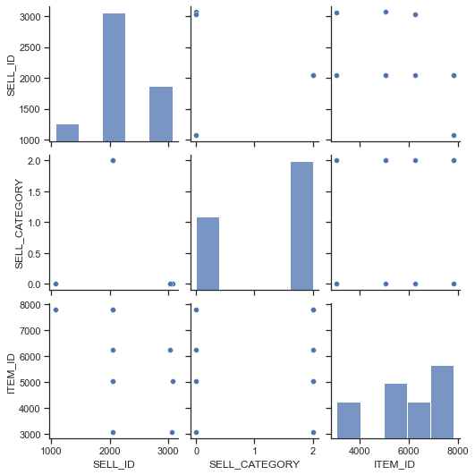

```python
sns.pairplot(sold)
```

```python
transactions.head()
```

|  | CALENDAR_DATE | PRICE | QUANTITY | SELL_ID | SELL_CATEGORY |
| --- | --- | --- | --- | --- | --- |
| 0 | 01/01/12 | 15.50 | 46 | 1070 | 0 |
| 1 | 01/01/12 | 12.73 | 22 | 2051 | 2 |
| 2 | 01/01/12 | 12.75 | 18 | 2052 | 2 |
| 3 | 01/01/12 | 12.60 | 30 | 2053 | 2 |
| 4 | 01/02/12 | 15.50 | 70 | 1070 | 0 |

```python
transactions.describe()
transactions.describe(include = ['O'])
```

|  | PRICE | QUANTITY | SELL_ID | SELL_CATEGORY |
| --- | --- | --- | --- | --- |
| count | 5404.000000 | 5404.000000 | 5404.00000 | 5404.000000 |
| mean | 12.868729 | 44.335307 | 1806.50000 | 1.500000 |
| std | 1.563922 | 25.502597 | 425.25841 | 0.866106 |
| min | 10.120000 | 8.000000 | 1070.00000 | 0.000000 |
| 25% | 11.530000 | 24.000000 | 1805.75000 | 1.500000 |
| 50% | 12.640000 | 36.000000 | 2051.50000 | 2.000000 |
| 75% | 13.557500 | 60.000000 | 2052.25000 | 2.000000 |
| max | 16.500000 | 124.000000 | 2053.00000 | 2.000000 |

|  | CALENDAR_DATE |
| --- | --- |
| count | 5404 |
| unique | 1348 |
| top | 03/01/13 |
| freq | 16 |

```python
transactions[transactions.isnull().any(axis=1)]
```

|  | CALENDAR_DATE | PRICE | QUANTITY | SELL_ID | SELL_CATEGORY |
| --- | --- | --- | --- | --- | --- |

Important: It’s supposed the PRICE for that product in that day will not vary.

In details: CALENDAR_DATE: a date/time variable, having the time always set to 00:00 AM.

PRICE: a numeric variable, associated with the price of the product identified by the SELL_ID.

QUANTITY: a numeric variable, associated with the quantity of the product sold, identified by the SELL_ID.

SELL_ID: a categorical variable, identifier of the product sold.

SELL_CATEGORY: a categorical variable, category of the product sold.

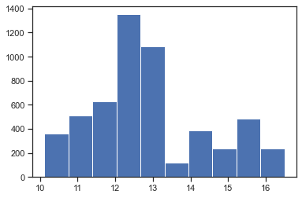

```python
plt.hist(transactions.PRICE)
```

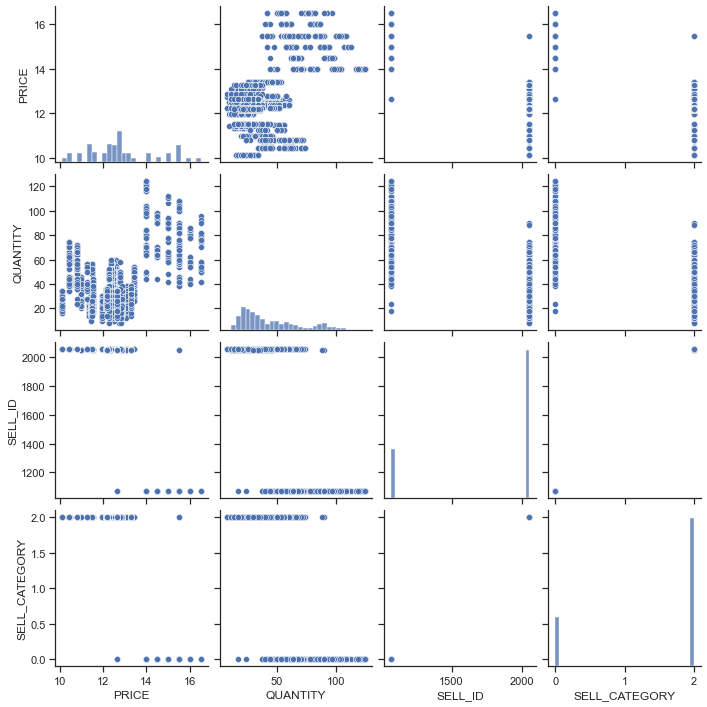

```python
sns.pairplot(transactions)
```

```python
date_info.head()
```

|  | CALENDAR_DATE | YEAR | HOLIDAY | IS_WEEKEND | IS_SCHOOLBREAK | AVERAGE_TEMPERATURE | IS_OUTDOOR |
| --- | --- | --- | --- | --- | --- | --- | --- |
| 0 | 1/1/12 | 2012 | New Year | 1 | 0 | 24.8 | 0 |
| 1 | 1/2/12 | 2012 | New Year | 0 | 0 | 24.8 | 0 |
| 2 | 1/3/12 | 2012 | New Year | 0 | 0 | 32.0 | 1 |
| 3 | 1/4/12 | 2012 | NaN | 0 | 0 | 32.0 | 1 |
| 4 | 1/5/12 | 2012 | NaN | 0 | 0 | 24.8 | 0 |

```python
date_info.describe()
date_info.describe(include = ['O'])
```

|  | YEAR | IS_WEEKEND | IS_SCHOOLBREAK | AVERAGE_TEMPERATURE | IS_OUTDOOR |
| --- | --- | --- | --- | --- | --- |
| count | 1349.000000 | 1349.000000 | 1349.000000 | 1349.000000 | 1349.000000 |
| mean | 2013.375093 | 0.285397 | 0.204596 | 56.326019 | 0.862120 |
| std | 1.073073 | 0.451771 | 0.403556 | 20.227597 | 0.344902 |
| min | 2012.000000 | 0.000000 | 0.000000 | 14.000000 | 0.000000 |
| 25% | 2012.000000 | 0.000000 | 0.000000 | 35.600000 | 1.000000 |
| 50% | 2013.000000 | 0.000000 | 0.000000 | 60.800000 | 1.000000 |
| 75% | 2014.000000 | 1.000000 | 0.000000 | 75.200000 | 1.000000 |
| max | 2015.000000 | 1.000000 | 1.000000 | 87.800000 | 1.000000 |

|  | CALENDAR_DATE | HOLIDAY |
| --- | --- | --- |
| count | 1349 | 105 |
| unique | 1348 | 8 |
| top | 3/1/13 | Luner New Year |
| freq | 2 | 28 |

```python
date_info.dtypes
```

```
CALENDAR_DATE           object
YEAR                     int64
HOLIDAY                 object
IS_WEEKEND               int64
IS_SCHOOLBREAK           int64
AVERAGE_TEMPERATURE    float64
IS_OUTDOOR               int64
dtype: object
```

```python
date_info[date_info.isnull().any(axis=1)]
```

|  | CALENDAR_DATE | YEAR | HOLIDAY | IS_WEEKEND | IS_SCHOOLBREAK | AVERAGE_TEMPERATURE | IS_OUTDOOR |
| --- | --- | --- | --- | --- | --- | --- | --- |
| 3 | 1/4/12 | 2012 | NaN | 0 | 0 | 32.0 | 1 |
| 4 | 1/5/12 | 2012 | NaN | 0 | 0 | 24.8 | 0 |
| 5 | 1/6/12 | 2012 | NaN | 0 | 0 | 23.0 | 0 |
| 6 | 1/7/12 | 2012 | NaN | 1 | 0 | 26.6 | 0 |
| 7 | 1/8/12 | 2012 | NaN | 1 | 0 | 26.6 | 0 |
| 8 | 1/9/12 | 2012 | NaN | 0 | 0 | 23.0 | 0 |
| 9 | 1/10/12 | 2012 | NaN | 0 | 0 | 24.8 | 0 |
| 10 | 1/11/12 | 2012 | NaN | 0 | 0 | 21.2 | 0 |
| 11 | 1/12/12 | 2012 | NaN | 0 | 0 | 24.8 | 0 |
| 12 | 1/13/12 | 2012 | NaN | 0 | 0 | 26.6 | 0 |
| 13 | 1/14/12 | 2012 | NaN | 1 | 0 | 23.0 | 0 |
| 14 | 1/15/12 | 2012 | NaN | 1 | 0 | 32.0 | 1 |
| 15 | 1/16/12 | 2012 | NaN | 0 | 0 | 23.0 | 0 |
| 16 | 1/17/12 | 2012 | NaN | 0 | 0 | 23.0 | 0 |
| 17 | 1/18/12 | 2012 | NaN | 0 | 0 | 23.0 | 0 |
| 18 | 1/19/12 | 2012 | NaN | 0 | 0 | 24.8 | 0 |
| 19 | 1/20/12 | 2012 | NaN | 0 | 0 | 26.6 | 0 |
| 20 | 1/21/12 | 2012 | NaN | 1 | 0 | 26.6 | 0 |
| 21 | 1/22/12 | 2012 | NaN | 1 | 0 | 24.8 | 0 |
| 22 | 1/23/12 | 2012 | NaN | 0 | 0 | 23.0 | 0 |
| 23 | 1/24/12 | 2012 | NaN | 0 | 0 | 24.8 | 0 |
| 24 | 1/25/12 | 2012 | NaN | 0 | 0 | 23.0 | 0 |
| 25 | 1/26/12 | 2012 | NaN | 0 | 0 | 24.8 | 0 |
| 26 | 1/27/12 | 2012 | NaN | 0 | 0 | 32.0 | 1 |
| 27 | 1/28/12 | 2012 | NaN | 1 | 0 | 32.0 | 1 |
| 28 | 1/29/12 | 2012 | NaN | 1 | 0 | 23.0 | 0 |
| 29 | 1/30/12 | 2012 | NaN | 0 | 0 | 28.4 | 0 |
| 30 | 1/31/12 | 2012 | NaN | 0 | 0 | 32.0 | 1 |
| 31 | 2/1/12 | 2012 | NaN | 0 | 0 | 32.0 | 1 |
| 39 | 2/9/12 | 2012 | NaN | 0 | 0 | 32.0 | 1 |

[output cut: 1214 more lines]

```python
date_info['HOLIDAY'] = date_info['HOLIDAY'].fillna("No Holiday")
```

```python
date_info
```

|  | CALENDAR_DATE | YEAR | HOLIDAY | IS_WEEKEND | IS_SCHOOLBREAK | AVERAGE_TEMPERATURE | IS_OUTDOOR |
| --- | --- | --- | --- | --- | --- | --- | --- |
| 0 | 1/1/12 | 2012 | New Year | 1 | 0 | 24.8 | 0 |
| 1 | 1/2/12 | 2012 | New Year | 0 | 0 | 24.8 | 0 |
| 2 | 1/3/12 | 2012 | New Year | 0 | 0 | 32.0 | 1 |
| 3 | 1/4/12 | 2012 | No Holiday | 0 | 0 | 32.0 | 1 |
| 4 | 1/5/12 | 2012 | No Holiday | 0 | 0 | 24.8 | 0 |
| 5 | 1/6/12 | 2012 | No Holiday | 0 | 0 | 23.0 | 0 |
| 6 | 1/7/12 | 2012 | No Holiday | 1 | 0 | 26.6 | 0 |
| 7 | 1/8/12 | 2012 | No Holiday | 1 | 0 | 26.6 | 0 |
| 8 | 1/9/12 | 2012 | No Holiday | 0 | 0 | 23.0 | 0 |
| 9 | 1/10/12 | 2012 | No Holiday | 0 | 0 | 24.8 | 0 |
| 10 | 1/11/12 | 2012 | No Holiday | 0 | 0 | 21.2 | 0 |
| 11 | 1/12/12 | 2012 | No Holiday | 0 | 0 | 24.8 | 0 |
| 12 | 1/13/12 | 2012 | No Holiday | 0 | 0 | 26.6 | 0 |
| 13 | 1/14/12 | 2012 | No Holiday | 1 | 0 | 23.0 | 0 |
| 14 | 1/15/12 | 2012 | No Holiday | 1 | 0 | 32.0 | 1 |
| 15 | 1/16/12 | 2012 | No Holiday | 0 | 0 | 23.0 | 0 |
| 16 | 1/17/12 | 2012 | No Holiday | 0 | 0 | 23.0 | 0 |
| 17 | 1/18/12 | 2012 | No Holiday | 0 | 0 | 23.0 | 0 |
| 18 | 1/19/12 | 2012 | No Holiday | 0 | 0 | 24.8 | 0 |
| 19 | 1/20/12 | 2012 | No Holiday | 0 | 0 | 26.6 | 0 |
| 20 | 1/21/12 | 2012 | No Holiday | 1 | 0 | 26.6 | 0 |
| 21 | 1/22/12 | 2012 | No Holiday | 1 | 0 | 24.8 | 0 |
| 22 | 1/23/12 | 2012 | No Holiday | 0 | 0 | 23.0 | 0 |
| 23 | 1/24/12 | 2012 | No Holiday | 0 | 0 | 24.8 | 0 |
| 24 | 1/25/12 | 2012 | No Holiday | 0 | 0 | 23.0 | 0 |
| 25 | 1/26/12 | 2012 | No Holiday | 0 | 0 | 24.8 | 0 |
| 26 | 1/27/12 | 2012 | No Holiday | 0 | 0 | 32.0 | 1 |
| 27 | 1/28/12 | 2012 | No Holiday | 1 | 0 | 32.0 | 1 |
| 28 | 1/29/12 | 2012 | No Holiday | 1 | 0 | 23.0 | 0 |
| 29 | 1/30/12 | 2012 | No Holiday | 0 | 0 | 28.4 | 0 |

[output cut: 1319 more lines]

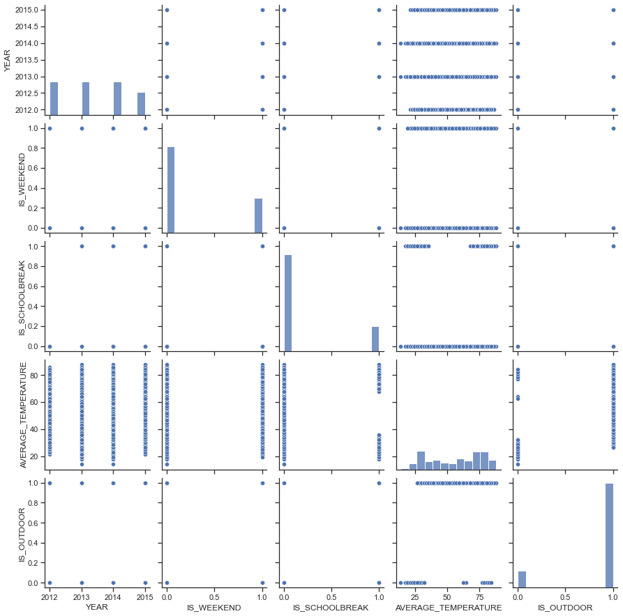

```python
sns.pairplot(date_info)
```

# Understanding the data better

```python
np.unique(date_info['HOLIDAY'])
```

```
array(['Dragon Boat Festivel', 'Labor Day', 'Luner New Year',
       'Mid-Autumn Day', 'National Day', 'New Year', 'No Holiday',
       'Qing Ming Festival', 'WWII Celebration'], dtype=object)
```

```python
date_info['CALENDAR_DATE'].min()
```

```
'1/1/12'
```

```python
date_info['CALENDAR_DATE'].max()
```

```
'9/9/15'
```

```python
date_info.shape
```

```
(1349, 7)
```

```python
date_info[date_info.isnull().any(axis=1)]
```

|  | CALENDAR_DATE | YEAR | HOLIDAY | IS_WEEKEND | IS_SCHOOLBREAK | AVERAGE_TEMPERATURE | IS_OUTDOOR |
| --- | --- | --- | --- | --- | --- | --- | --- |

```python
# ------------------------------------------------------------------------------------------------------
```

```python
pd.concat([sold.SELL_ID, pd.get_dummies(sold.ITEM_NAME)], axis=1)
```

|  | SELL_ID | BURGER | COFFEE | COKE | LEMONADE |
| --- | --- | --- | --- | --- | --- |
| 0 | 1070 | 1 | 0 | 0 | 0 |
| 1 | 3055 | 0 | 1 | 0 | 0 |
| 2 | 3067 | 0 | 0 | 1 | 0 |
| 3 | 3028 | 0 | 0 | 0 | 1 |
| 4 | 2051 | 1 | 0 | 0 | 0 |
| 5 | 2051 | 0 | 0 | 1 | 0 |
| 6 | 2052 | 1 | 0 | 0 | 0 |
| 7 | 2052 | 0 | 0 | 0 | 1 |
| 8 | 2053 | 1 | 0 | 0 | 0 |
| 9 | 2053 | 0 | 0 | 1 | 0 |
| 10 | 2053 | 0 | 1 | 0 | 0 |

```python
pd.concat([sold.SELL_ID, pd.get_dummies(sold.ITEM_NAME)], axis=1).groupby(sold.SELL_ID).sum()
```

| SELL_ID | SELL_ID | BURGER | COFFEE | COKE | LEMONADE |
| --- | --- | --- | --- | --- | --- |
| 1070 | 1070 | 1 | 0 | 0 | 0 |
| 2051 | 4102 | 1 | 0 | 1 | 0 |
| 2052 | 4104 | 1 | 0 | 0 | 1 |
| 2053 | 6159 | 1 | 1 | 1 | 0 |
| 3028 | 3028 | 0 | 0 | 0 | 1 |
| 3055 | 3055 | 0 | 1 | 0 | 0 |
| 3067 | 3067 | 0 | 0 | 1 | 0 |

```python
data1 = pd.merge(sold.drop(['ITEM_ID'],axis=1), transactions.drop(['SELL_CATEGORY'], axis= 1), on =  'SELL_ID')
data1.head(20)
b = data1.groupby(['SELL_ID', 'SELL_CATEGORY', 'ITEM_NAME', 'CALENDAR_DATE','PRICE']).QUANTITY.sum()
```

|  | SELL_ID | SELL_CATEGORY | ITEM_NAME | CALENDAR_DATE | PRICE | QUANTITY |
| --- | --- | --- | --- | --- | --- | --- |
| 0 | 1070 | 0 | BURGER | 01/01/12 | 15.5 | 46 |
| 1 | 1070 | 0 | BURGER | 01/02/12 | 15.5 | 70 |
| 2 | 1070 | 0 | BURGER | 01/03/12 | 15.5 | 62 |
| 3 | 1070 | 0 | BURGER | 01/04/12 | 15.5 | 88 |
| 4 | 1070 | 0 | BURGER | 01/05/12 | 15.5 | 104 |
| 5 | 1070 | 0 | BURGER | 01/06/12 | 15.5 | 100 |
| 6 | 1070 | 0 | BURGER | 01/07/12 | 15.5 | 70 |
| 7 | 1070 | 0 | BURGER | 01/08/12 | 15.5 | 70 |
| 8 | 1070 | 0 | BURGER | 01/09/12 | 15.5 | 106 |
| 9 | 1070 | 0 | BURGER | 01/10/12 | 15.5 | 108 |
| 10 | 1070 | 0 | BURGER | 01/11/12 | 15.5 | 104 |
| 11 | 1070 | 0 | BURGER | 01/12/12 | 15.5 | 102 |
| 12 | 1070 | 0 | BURGER | 1/13/12 | 15.5 | 100 |
| 13 | 1070 | 0 | BURGER | 1/14/12 | 15.5 | 74 |
| 14 | 1070 | 0 | BURGER | 1/15/12 | 15.5 | 60 |
| 15 | 1070 | 0 | BURGER | 1/16/12 | 15.5 | 104 |
| 16 | 1070 | 0 | BURGER | 1/17/12 | 15.5 | 106 |
| 17 | 1070 | 0 | BURGER | 1/18/12 | 15.5 | 108 |
| 18 | 1070 | 0 | BURGER | 1/19/12 | 15.5 | 100 |
| 19 | 1070 | 0 | BURGER | 1/20/12 | 15.5 | 100 |

```python
b
```

```
SELL_ID  SELL_CATEGORY  ITEM_NAME  CALENDAR_DATE  PRICE
1070     0              BURGER     01/01/12       15.50     46
                                   01/01/13       15.50     60
                                   01/01/14       15.50     72
                                   01/01/15       14.00     66
                                   01/02/12       15.50     70
                                   01/02/13       15.50     68
                                   01/02/14       15.50     76
                                   01/02/15       14.00    102
                                   01/03/12       15.50     62
                                   01/03/13       15.50     70
                                   01/03/14       15.50     68
                                   01/03/15       14.00     68
                                   01/04/12       15.50     88
                                   01/04/13       15.50    100
                                   01/04/14       15.50     74
                                   01/04/15       14.00     70
                                   01/05/12       15.50    104
                                   01/05/13       15.50     68
                                   01/05/14       15.50     70
                                   01/05/15       14.00    104
                                   01/06/12       15.50    100
                                   01/06/13       15.50     72
                                   01/06/14       15.50    108
                                   01/06/15       14.00     98
                                   01/07/12       15.50     70
                                   01/07/13       15.50    100
                                   01/07/14       15.50    100
                                   01/07/15       14.00    104
                                   01/08/12       15.50     70
                                   01/08/13       15.50    100
                                   01/08/14       15.50    104
                                   01/08/15       14.00    120
                                   01/09/12       15.50    106
                                   01/09/13       15.50    102
                                   01/09/14       15.50    102
                                   01/09/15       14.00    124
                                   01/10/12       15.50    108
                                   01/10/13       15.50    104
                                   01/10/14       15.50    102
```

[output cut: 10739 more lines]

```
                                   9/26/13        10.45     64
                                   9/26/14        12.77     44
                                   9/27/12        12.42     50
                                   9/27/13        10.45     62
                                   9/27/14        12.77     28
                                   9/28/12        12.42     50
                                   9/28/13        10.45     46
                                   9/28/14        12.77     30
                                   9/29/12        12.42     36
                                   9/29/13        10.45     40
                                   9/29/14        12.77     46
                                   9/30/12        12.42     38
                                   9/30/13        10.45     38
                                   9/30/14        12.77     50
Name: QUANTITY, dtype: int64
```

```python
data1.shape
intermediate_data = b.reset_index()
```

```
(10808, 6)
```

```python
data1.shape
```

```
(10808, 6)
```

```python
b.shape
```

```
(10792,)
```

```python
intermediate_data.head()
```

|  | SELL_ID | SELL_CATEGORY | ITEM_NAME | CALENDAR_DATE | PRICE | QUANTITY |
| --- | --- | --- | --- | --- | --- | --- |
| 0 | 1070 | 0 | BURGER | 01/01/12 | 15.5 | 46 |
| 1 | 1070 | 0 | BURGER | 01/01/13 | 15.5 | 60 |
| 2 | 1070 | 0 | BURGER | 01/01/14 | 15.5 | 72 |
| 3 | 1070 | 0 | BURGER | 01/01/15 | 14.0 | 66 |
| 4 | 1070 | 0 | BURGER | 01/02/12 | 15.5 | 70 |

```python
intermediate_data['CALENDAR_DATE'].min()
```

```
'01/01/12'
```

```python
intermediate_data['CALENDAR_DATE'].max()
```

```
'9/30/14'
```

```python
combined_data = pd.merge(intermediate_data, date_info, on = 'CALENDAR_DATE')
combined_data.head()
```

|  | SELL_ID | SELL_CATEGORY | ITEM_NAME | CALENDAR_DATE | PRICE | QUANTITY | YEAR | HOLIDAY | IS_WEEKEND | IS_SCHOOLBREAK | AVERAGE_TEMPERATURE | IS_OUTDOOR |
| --- | --- | --- | --- | --- | --- | --- | --- | --- | --- | --- | --- | --- |
| 0 | 1070 | 0 | BURGER | 1/13/12 | 15.50 | 100 | 2012 | No Holiday | 0 | 0 | 26.6 | 0 |
| 1 | 2051 | 2 | BURGER | 1/13/12 | 12.73 | 40 | 2012 | No Holiday | 0 | 0 | 26.6 | 0 |
| 2 | 2051 | 2 | COKE | 1/13/12 | 12.73 | 40 | 2012 | No Holiday | 0 | 0 | 26.6 | 0 |
| 3 | 2052 | 2 | BURGER | 1/13/12 | 12.75 | 26 | 2012 | No Holiday | 0 | 0 | 26.6 | 0 |
| 4 | 2052 | 2 | LEMONADE | 1/13/12 | 12.75 | 26 | 2012 | No Holiday | 0 | 0 | 26.6 | 0 |

```python
combined_data.shape
```

```
(6696, 12)
```

```python
combined_data[combined_data.isnull().any(axis=1)]
```

|  | SELL_ID | SELL_CATEGORY | ITEM_NAME | CALENDAR_DATE | PRICE | QUANTITY | YEAR | HOLIDAY | IS_WEEKEND | IS_SCHOOLBREAK | AVERAGE_TEMPERATURE | IS_OUTDOOR |
| --- | --- | --- | --- | --- | --- | --- | --- | --- | --- | --- | --- | --- |

```python
np.unique(combined_data['HOLIDAY'])
np.unique(combined_data['IS_WEEKEND'])
np.unique(combined_data['IS_SCHOOLBREAK'])
```

```
array(['Dragon Boat Festivel', 'Labor Day', 'Luner New Year',
       'Mid-Autumn Day', 'No Holiday'], dtype=object)
```

```
array([0, 1])
```

```
array([0, 1])
```

```python
bau_data = combined_data[(combined_data['HOLIDAY']=='No Holiday') & (combined_data['IS_SCHOOLBREAK']==0) & (combined_data['IS_WEEKEND']==0)]
```

```python
bau_data.head()
```

|  | SELL_ID | SELL_CATEGORY | ITEM_NAME | CALENDAR_DATE | PRICE | QUANTITY | YEAR | HOLIDAY | IS_WEEKEND | IS_SCHOOLBREAK | AVERAGE_TEMPERATURE | IS_OUTDOOR |
| --- | --- | --- | --- | --- | --- | --- | --- | --- | --- | --- | --- | --- |
| 0 | 1070 | 0 | BURGER | 1/13/12 | 15.50 | 100 | 2012 | No Holiday | 0 | 0 | 26.6 | 0 |
| 1 | 2051 | 2 | BURGER | 1/13/12 | 12.73 | 40 | 2012 | No Holiday | 0 | 0 | 26.6 | 0 |
| 2 | 2051 | 2 | COKE | 1/13/12 | 12.73 | 40 | 2012 | No Holiday | 0 | 0 | 26.6 | 0 |
| 3 | 2052 | 2 | BURGER | 1/13/12 | 12.75 | 26 | 2012 | No Holiday | 0 | 0 | 26.6 | 0 |
| 4 | 2052 | 2 | LEMONADE | 1/13/12 | 12.75 | 26 | 2012 | No Holiday | 0 | 0 | 26.6 | 0 |

```python
bau_data.shape
```

```
(3768, 12)
```

```python
np.unique(bau_data['HOLIDAY'])
np.unique(bau_data['IS_WEEKEND'])
np.unique(bau_data['IS_SCHOOLBREAK'])
```

```
array(['No Holiday'], dtype=object)
```

```
array([0])
```

```
array([0])
```

```python
bau_data[bau_data['IS_WEEKEND']==1]
```

|  | SELL_ID | SELL_CATEGORY | ITEM_NAME | CALENDAR_DATE | PRICE | QUANTITY | YEAR | HOLIDAY | IS_WEEKEND | IS_SCHOOLBREAK | AVERAGE_TEMPERATURE | IS_OUTDOOR |
| --- | --- | --- | --- | --- | --- | --- | --- | --- | --- | --- | --- | --- |

```python
bau_data[bau_data['HOLIDAY']!='No Holiday']
```

|  | SELL_ID | SELL_CATEGORY | ITEM_NAME | CALENDAR_DATE | PRICE | QUANTITY | YEAR | HOLIDAY | IS_WEEKEND | IS_SCHOOLBREAK | AVERAGE_TEMPERATURE | IS_OUTDOOR |
| --- | --- | --- | --- | --- | --- | --- | --- | --- | --- | --- | --- | --- |

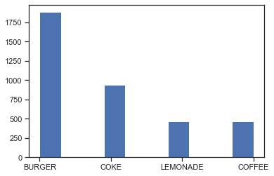

```python
# Data exploration
plt.hist(bau_data.ITEM_NAME)
```

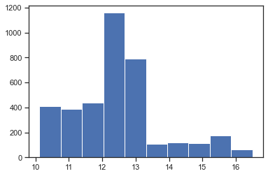

```python
plt.hist(bau_data.PRICE)
```

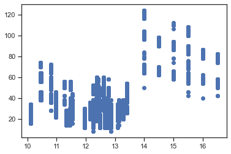

```python
plt.scatter(combined_data['PRICE'], combined_data['QUANTITY'])
```

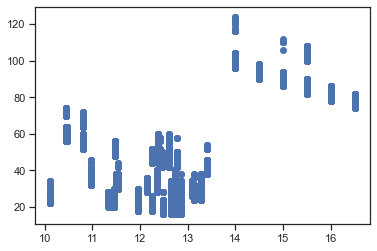

```python
plt.scatter(bau_data['PRICE'], bau_data['QUANTITY'])
```

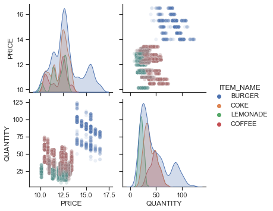

```python
sns.pairplot(combined_data[['PRICE','QUANTITY','ITEM_NAME']], hue = 'ITEM_NAME', plot_kws={'alpha':0.1})
```

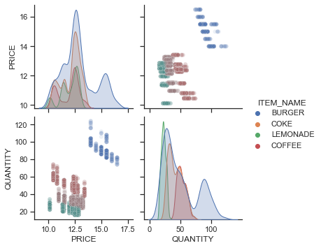

```python
sns.pairplot(bau_data[['PRICE','QUANTITY','ITEM_NAME']], hue = 'ITEM_NAME', plot_kws={'alpha':0.1})
```

|  | SELL_ID | SELL_CATEGORY | ITEM_NAME | CALENDAR_DATE | PRICE | QUANTITY | YEAR | HOLIDAY | IS_WEEKEND | IS_SCHOOLBREAK | AVERAGE_TEMPERATURE | IS_OUTDOOR |
| --- | --- | --- | --- | --- | --- | --- | --- | --- | --- | --- | --- | --- |
| 0 | 1070 | 0 | BURGER | 1/13/12 | 15.50 | 100 | 2012 | No Holiday | 0 | 0 | 26.6 | 0 |
| 1 | 2051 | 2 | BURGER | 1/13/12 | 12.73 | 40 | 2012 | No Holiday | 0 | 0 | 26.6 | 0 |
| 3 | 2052 | 2 | BURGER | 1/13/12 | 12.75 | 26 | 2012 | No Holiday | 0 | 0 | 26.6 | 0 |
| 5 | 2053 | 2 | BURGER | 1/13/12 | 12.60 | 58 | 2012 | No Holiday | 0 | 0 | 26.6 | 0 |
| 8 | 1070 | 0 | BURGER | 1/13/13 | 15.50 | 70 | 2013 | No Holiday | 1 | 0 | 30.2 | 0 |

```
(3348, 12)
```

|  | SELL_ID | SELL_CATEGORY | PRICE | QUANTITY | YEAR | IS_WEEKEND | IS_SCHOOLBREAK | AVERAGE_TEMPERATURE | IS_OUTDOOR |
| --- | --- | --- | --- | --- | --- | --- | --- | --- | --- |
| count | 3348.000000 | 3348.000000 | 3348.000000 | 3348.000000 | 3348.000000 | 3348.000000 | 3348.000000 | 3348.000000 | 3348.000000 |
| mean | 1806.500000 | 1.500000 | 12.858572 | 44.974313 | 2013.351254 | 0.284349 | 0.200717 | 56.255914 | 0.878136 |
| std | 425.282579 | 0.866155 | 1.565046 | 25.747886 | 1.062567 | 0.451171 | 0.400596 | 19.996348 | 0.327177 |
| min | 1070.000000 | 0.000000 | 10.120000 | 8.000000 | 2012.000000 | 0.000000 | 0.000000 | 14.000000 | 0.000000 |
| 25% | 1805.750000 | 1.500000 | 11.530000 | 24.000000 | 2012.000000 | 0.000000 | 0.000000 | 35.600000 | 1.000000 |
| 50% | 2051.500000 | 2.000000 | 12.640000 | 36.000000 | 2013.000000 | 0.000000 | 0.000000 | 59.000000 | 1.000000 |
| 75% | 2052.250000 | 2.000000 | 13.557500 | 60.000000 | 2014.000000 | 1.000000 | 0.000000 | 75.200000 | 1.000000 |
| max | 2053.000000 | 2.000000 | 16.500000 | 124.000000 | 2015.000000 | 1.000000 | 1.000000 | 87.800000 | 1.000000 |

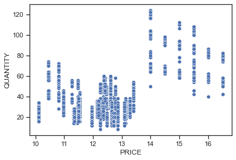

```python
burger = combined_data[combined_data['ITEM_NAME'] == 'BURGER']
burger.head()
burger.shape
burger.describe()
sns.scatterplot(x = burger.PRICE, y = burger.QUANTITY )
```

From the above scatter plot it is clearly visible that there must be different types of burgers being sold. Now let's see the same distributin whenwe differentiate with SELL_ID which indicates if the burger was a part of the combo and hence, must be treated separately.

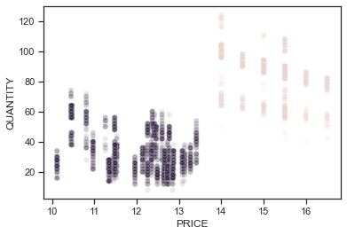

```python
burger = combined_data[combined_data['ITEM_NAME'] == 'BURGER']
# print(burger)
# print(burger.describe())
sns.scatterplot(data = burger, x = burger.PRICE, y = burger.QUANTITY , hue = 'SELL_ID', legend=False, alpha = 0.1)
```

```python
np.unique(combined_data.SELL_ID)
```

```
array([1070, 2051, 2052, 2053])
```

```python
np.unique(combined_data.SELL_CATEGORY)
```

```
array([0, 2])
```

|  | SELL_ID | SELL_CATEGORY | ITEM_NAME | CALENDAR_DATE | PRICE | QUANTITY | YEAR | HOLIDAY | IS_WEEKEND | IS_SCHOOLBREAK | AVERAGE_TEMPERATURE | IS_OUTDOOR |
| --- | --- | --- | --- | --- | --- | --- | --- | --- | --- | --- | --- | --- |
| 0 | 1070 | 0 | BURGER | 1/13/12 | 15.5 | 100 | 2012 | No Holiday | 0 | 0 | 26.6 | 0 |
| 8 | 1070 | 0 | BURGER | 1/13/13 | 15.5 | 70 | 2013 | No Holiday | 1 | 0 | 30.2 | 0 |
| 16 | 1070 | 0 | BURGER | 1/13/14 | 15.5 | 104 | 2014 | No Holiday | 0 | 0 | 28.4 | 0 |
| 24 | 1070 | 0 | BURGER | 1/13/15 | 14.0 | 116 | 2015 | No Holiday | 0 | 0 | 28.4 | 0 |
| 32 | 1070 | 0 | BURGER | 1/14/12 | 15.5 | 74 | 2012 | No Holiday | 1 | 0 | 23.0 | 0 |

|  | SELL_ID | SELL_CATEGORY | PRICE | QUANTITY | YEAR | IS_WEEKEND | IS_SCHOOLBREAK | AVERAGE_TEMPERATURE | IS_OUTDOOR |
| --- | --- | --- | --- | --- | --- | --- | --- | --- | --- |
| count | 837.0 | 837.0 | 837.000000 | 837.000000 | 837.000000 | 837.000000 | 837.000000 | 837.000000 | 837.000000 |
| mean | 1070.0 | 0.0 | 15.154719 | 82.685783 | 2013.351254 | 0.284349 | 0.200717 | 56.255914 | 0.878136 |
| std | 0.0 | 0.0 | 0.744770 | 15.981238 | 1.063043 | 0.451373 | 0.400776 | 20.005316 | 0.327324 |
| min | 1070.0 | 0.0 | 14.000000 | 40.000000 | 2012.000000 | 0.000000 | 0.000000 | 14.000000 | 0.000000 |
| 25% | 1070.0 | 0.0 | 14.500000 | 68.000000 | 2012.000000 | 0.000000 | 0.000000 | 35.600000 | 1.000000 |
| 50% | 1070.0 | 0.0 | 15.500000 | 86.000000 | 2013.000000 | 0.000000 | 0.000000 | 59.000000 | 1.000000 |
| 75% | 1070.0 | 0.0 | 15.500000 | 92.000000 | 2014.000000 | 1.000000 | 0.000000 | 75.200000 | 1.000000 |
| max | 1070.0 | 0.0 | 16.500000 | 124.000000 | 2015.000000 | 1.000000 | 1.000000 | 87.800000 | 1.000000 |

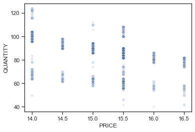

```python
burger_1070 = combined_data[(combined_data['ITEM_NAME'] == 'BURGER') & (combined_data['SELL_ID'] == 1070)]

burger_1070.head()
burger_1070.describe()
sns.scatterplot(data = burger_1070, x = burger_1070.PRICE, y = burger_1070.QUANTITY, alpha = 0.1)
```

# Modeling

```
                            OLS Regression Results
==============================================================================
Dep. Variable:               QUANTITY   R-squared:                       0.156
Model:                            OLS   Adj. R-squared:                  0.155
Method:                 Least Squares   F-statistic:                     153.9
Date:                Mon, 07 Jun 2021   Prob (F-statistic):           1.45e-32
Time:                        21:38:25   Log-Likelihood:                -3436.0
No. Observations:                 837   AIC:                             6876.
Df Residuals:                     835   BIC:                             6885.
Df Model:                           1
Covariance Type:            nonrobust
==============================================================================
                 coef    std err          t      P>|t|      [0.025      0.975]
------------------------------------------------------------------------------
Intercept    210.9859     10.353     20.379      0.000     190.665     231.307
PRICE         -8.4660      0.682    -12.407      0.000      -9.805      -7.127
==============================================================================
Omnibus:                       42.869   Durbin-Watson:                   1.714
Prob(Omnibus):                  0.000   Jarque-Bera (JB):               34.664
Skew:                          -0.414   Prob(JB):                     2.97e-08
Kurtosis:                       2.446   Cond. No.                         311.
==============================================================================

Notes:
[1] Standard Errors assume that the covariance matrix of the errors is correctly specified.
```

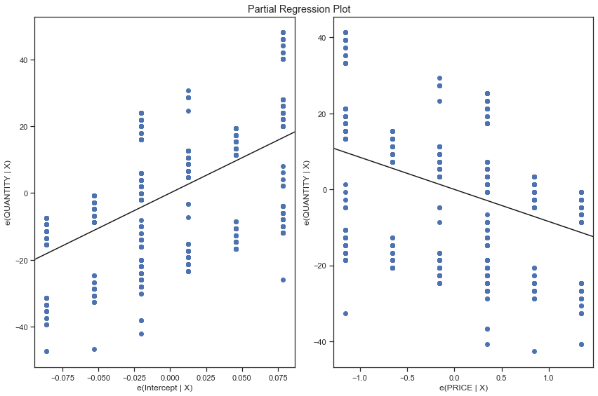

```python
# This is for the combined data
burger_model = ols("QUANTITY ~ PRICE", data=burger_1070).fit()
print(burger_model.summary())
fig = plt.figure(figsize=(12,8))
fig = sm.graphics.plot_partregress_grid(burger_model, fig=fig)
```

|  | SELL_ID | SELL_CATEGORY | ITEM_NAME | CALENDAR_DATE | PRICE | QUANTITY | YEAR | HOLIDAY | IS_WEEKEND | IS_SCHOOLBREAK | AVERAGE_TEMPERATURE | IS_OUTDOOR |
| --- | --- | --- | --- | --- | --- | --- | --- | --- | --- | --- | --- | --- |
| 0 | 1070 | 0 | BURGER | 1/13/12 | 15.50 | 100 | 2012 | No Holiday | 0 | 0 | 26.6 | 0 |
| 1 | 2051 | 2 | BURGER | 1/13/12 | 12.73 | 40 | 2012 | No Holiday | 0 | 0 | 26.6 | 0 |
| 3 | 2052 | 2 | BURGER | 1/13/12 | 12.75 | 26 | 2012 | No Holiday | 0 | 0 | 26.6 | 0 |
| 5 | 2053 | 2 | BURGER | 1/13/12 | 12.60 | 58 | 2012 | No Holiday | 0 | 0 | 26.6 | 0 |
| 16 | 1070 | 0 | BURGER | 1/13/14 | 15.50 | 104 | 2014 | No Holiday | 0 | 0 | 28.4 | 0 |

```
(1884, 12)
```

|  | SELL_ID | SELL_CATEGORY | PRICE | QUANTITY | YEAR | IS_WEEKEND | IS_SCHOOLBREAK | AVERAGE_TEMPERATURE | IS_OUTDOOR |
| --- | --- | --- | --- | --- | --- | --- | --- | --- | --- |
| count | 1884.000000 | 1884.000000 | 1884.000000 | 1884.000000 | 1884.000000 | 1884.0 | 1884.0 | 1884.000000 | 1884.000000 |
| mean | 1806.500000 | 1.500000 | 12.830340 | 49.562633 | 2013.186837 | 0.0 | 0.0 | 53.691720 | 0.883227 |
| std | 425.331956 | 0.866255 | 1.567257 | 27.309516 | 1.058620 | 0.0 | 0.0 | 18.721922 | 0.321235 |
| min | 1070.000000 | 0.000000 | 10.120000 | 16.000000 | 2012.000000 | 0.0 | 0.0 | 14.000000 | 0.000000 |
| 25% | 1805.750000 | 1.500000 | 11.530000 | 28.000000 | 2012.000000 | 0.0 | 0.0 | 35.600000 | 1.000000 |
| 50% | 2051.500000 | 2.000000 | 12.640000 | 40.000000 | 2013.000000 | 0.0 | 0.0 | 53.600000 | 1.000000 |
| 75% | 2052.250000 | 2.000000 | 13.557500 | 74.000000 | 2014.000000 | 0.0 | 0.0 | 71.600000 | 1.000000 |
| max | 2053.000000 | 2.000000 | 16.500000 | 124.000000 | 2015.000000 | 0.0 | 0.0 | 87.800000 | 1.000000 |

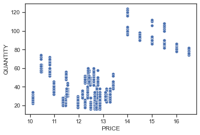

```python
burger = bau_data[bau_data['ITEM_NAME'] == 'BURGER']
burger.head()
burger.shape
burger.describe()
sns.scatterplot(x = burger.PRICE, y = burger.QUANTITY )
```

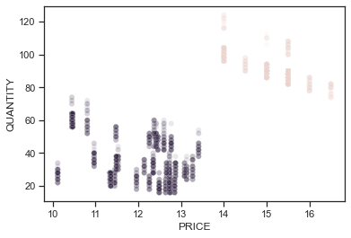

```python
burger = bau_data[bau_data['ITEM_NAME'] == 'BURGER']
# print(burger)
# print(burger.describe())
sns.scatterplot(data = burger, x = burger.PRICE, y = burger.QUANTITY , hue = 'SELL_ID', legend=False, alpha = 0.1)
```

```python
np.unique(bau_data.SELL_ID)
```

```
array([1070, 2051, 2052, 2053])
```

```python
np.unique(bau_data.SELL_CATEGORY)
```

```
array([0, 2])
```

|  | SELL_ID | SELL_CATEGORY | ITEM_NAME | CALENDAR_DATE | PRICE | QUANTITY | YEAR | HOLIDAY | IS_WEEKEND | IS_SCHOOLBREAK | AVERAGE_TEMPERATURE | IS_OUTDOOR |
| --- | --- | --- | --- | --- | --- | --- | --- | --- | --- | --- | --- | --- |
| 0 | 1070 | 0 | BURGER | 1/13/12 | 15.5 | 100 | 2012 | No Holiday | 0 | 0 | 26.6 | 0 |
| 16 | 1070 | 0 | BURGER | 1/13/14 | 15.5 | 104 | 2014 | No Holiday | 0 | 0 | 28.4 | 0 |
| 24 | 1070 | 0 | BURGER | 1/13/15 | 14.0 | 116 | 2015 | No Holiday | 0 | 0 | 28.4 | 0 |
| 48 | 1070 | 0 | BURGER | 1/14/14 | 15.5 | 86 | 2014 | No Holiday | 0 | 0 | 28.4 | 1 |
| 56 | 1070 | 0 | BURGER | 1/14/15 | 14.0 | 122 | 2015 | No Holiday | 0 | 0 | 30.2 | 0 |

|  | SELL_ID | SELL_CATEGORY | PRICE | QUANTITY | YEAR | IS_WEEKEND | IS_SCHOOLBREAK | AVERAGE_TEMPERATURE | IS_OUTDOOR |
| --- | --- | --- | --- | --- | --- | --- | --- | --- | --- |
| count | 471.0 | 471.0 | 471.000000 | 471.000000 | 471.000000 | 471.0 | 471.0 | 471.000000 | 471.000000 |
| mean | 1070.0 | 0.0 | 15.124204 | 91.622081 | 2013.186837 | 0.0 | 0.0 | 53.691720 | 0.883227 |
| std | 0.0 | 0.0 | 0.705577 | 9.437897 | 1.059464 | 0.0 | 0.0 | 18.736854 | 0.321491 |
| min | 1070.0 | 0.0 | 14.000000 | 74.000000 | 2012.000000 | 0.0 | 0.0 | 14.000000 | 0.000000 |
| 25% | 1070.0 | 0.0 | 14.500000 | 86.000000 | 2012.000000 | 0.0 | 0.0 | 35.600000 | 1.000000 |
| 50% | 1070.0 | 0.0 | 15.500000 | 90.000000 | 2013.000000 | 0.0 | 0.0 | 53.600000 | 1.000000 |
| 75% | 1070.0 | 0.0 | 15.500000 | 98.000000 | 2014.000000 | 0.0 | 0.0 | 70.700000 | 1.000000 |
| max | 1070.0 | 0.0 | 16.500000 | 124.000000 | 2015.000000 | 0.0 | 0.0 | 87.800000 | 1.000000 |

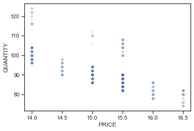

```python
burger_1070 = bau_data[(bau_data['ITEM_NAME'] == 'BURGER') & (bau_data['SELL_ID'] == 1070)]

burger_1070.head()
burger_1070.describe()
sns.scatterplot(data = burger_1070, x = burger_1070.PRICE, y = burger_1070.QUANTITY, alpha = 0.1)
```

As you can see, the scatter plot is much cleaner. Although there does seem to be 2 separate trends

```
                            OLS Regression Results
==============================================================================
Dep. Variable:               QUANTITY   R-squared:                       0.486
Model:                            OLS   Adj. R-squared:                  0.485
Method:                 Least Squares   F-statistic:                     444.2
Date:                Mon, 07 Jun 2021   Prob (F-statistic):           7.16e-70
Time:                        21:38:26   Log-Likelihood:                -1568.2
No. Observations:                 471   AIC:                             3140.
Df Residuals:                     469   BIC:                             3149.
Df Model:                           1
Covariance Type:            nonrobust
==============================================================================
                 coef    std err          t      P>|t|      [0.025      0.975]
------------------------------------------------------------------------------
Intercept    232.7193      6.702     34.726      0.000     219.550     245.888
PRICE         -9.3292      0.443    -21.077      0.000     -10.199      -8.459
==============================================================================
Omnibus:                      152.164   Durbin-Watson:                   1.040
Prob(Omnibus):                  0.000   Jarque-Bera (JB):              339.594
Skew:                           1.724   Prob(JB):                     1.81e-74
Kurtosis:                       5.326   Cond. No.                         327.
==============================================================================

Notes:
[1] Standard Errors assume that the covariance matrix of the errors is correctly specified.
```

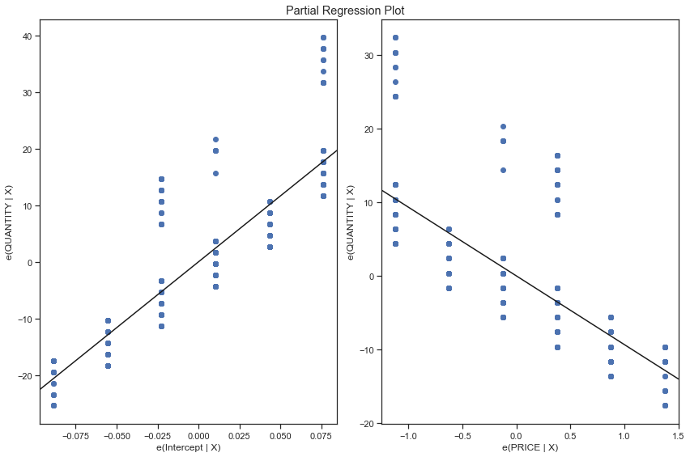

```python
burger_model = ols("QUANTITY ~ PRICE", data=burger_1070).fit()
print(burger_model.summary())
fig = plt.figure(figsize=(12,8))
fig = sm.graphics.plot_partregress_grid(burger_model, fig=fig)
```

Let's look at the bau data again to see if there is anything els ein the data we can use to further refine our model.

```python
bau_data.head()
```

|  | SELL_ID | SELL_CATEGORY | ITEM_NAME | CALENDAR_DATE | PRICE | QUANTITY | YEAR | HOLIDAY | IS_WEEKEND | IS_SCHOOLBREAK | AVERAGE_TEMPERATURE | IS_OUTDOOR |
| --- | --- | --- | --- | --- | --- | --- | --- | --- | --- | --- | --- | --- |
| 0 | 1070 | 0 | BURGER | 1/13/12 | 15.50 | 100 | 2012 | No Holiday | 0 | 0 | 26.6 | 0 |
| 1 | 2051 | 2 | BURGER | 1/13/12 | 12.73 | 40 | 2012 | No Holiday | 0 | 0 | 26.6 | 0 |
| 2 | 2051 | 2 | COKE | 1/13/12 | 12.73 | 40 | 2012 | No Holiday | 0 | 0 | 26.6 | 0 |
| 3 | 2052 | 2 | BURGER | 1/13/12 | 12.75 | 26 | 2012 | No Holiday | 0 | 0 | 26.6 | 0 |
| 4 | 2052 | 2 | LEMONADE | 1/13/12 | 12.75 | 26 | 2012 | No Holiday | 0 | 0 | 26.6 | 0 |

```python
bau2_data = combined_data[(combined_data['HOLIDAY']=='No Holiday') & (combined_data['IS_SCHOOLBREAK']==0) & (combined_data['IS_WEEKEND']==0) & (combined_data['IS_OUTDOOR']==1)]
```

|  | SELL_ID | SELL_CATEGORY | ITEM_NAME | CALENDAR_DATE | PRICE | QUANTITY | YEAR | HOLIDAY | IS_WEEKEND | IS_SCHOOLBREAK | AVERAGE_TEMPERATURE | IS_OUTDOOR |
| --- | --- | --- | --- | --- | --- | --- | --- | --- | --- | --- | --- | --- |
| 48 | 1070 | 0 | BURGER | 1/14/14 | 15.5 | 86 | 2014 | No Holiday | 0 | 0 | 28.4 | 1 |
| 88 | 1070 | 0 | BURGER | 1/15/15 | 14.0 | 104 | 2015 | No Holiday | 0 | 0 | 32.0 | 1 |
| 120 | 1070 | 0 | BURGER | 1/16/15 | 14.0 | 100 | 2015 | No Holiday | 0 | 0 | 32.0 | 1 |
| 448 | 1070 | 0 | BURGER | 1/27/12 | 15.5 | 86 | 2012 | No Holiday | 0 | 0 | 32.0 | 1 |
| 576 | 1070 | 0 | BURGER | 1/31/12 | 15.5 | 84 | 2012 | No Holiday | 0 | 0 | 32.0 | 1 |

|  | SELL_ID | SELL_CATEGORY | PRICE | QUANTITY | YEAR | IS_WEEKEND | IS_SCHOOLBREAK | AVERAGE_TEMPERATURE | IS_OUTDOOR |
| --- | --- | --- | --- | --- | --- | --- | --- | --- | --- |
| count | 416.0 | 416.0 | 416.000000 | 416.000000 | 416.000000 | 416.0 | 416.0 | 416.000000 | 416.0 |
| mean | 1070.0 | 0.0 | 15.139423 | 89.274038 | 2013.201923 | 0.0 | 0.0 | 57.282212 | 1.0 |
| std | 0.0 | 0.0 | 0.709511 | 6.811889 | 1.076628 | 0.0 | 0.0 | 16.890613 | 0.0 |
| min | 1070.0 | 0.0 | 14.000000 | 74.000000 | 2012.000000 | 0.0 | 0.0 | 26.600000 | 1.0 |
| 25% | 1070.0 | 0.0 | 14.500000 | 84.000000 | 2012.000000 | 0.0 | 0.0 | 41.000000 | 1.0 |
| 50% | 1070.0 | 0.0 | 15.000000 | 88.000000 | 2013.000000 | 0.0 | 0.0 | 59.000000 | 1.0 |
| 75% | 1070.0 | 0.0 | 15.500000 | 94.000000 | 2014.000000 | 0.0 | 0.0 | 71.600000 | 1.0 |
| max | 1070.0 | 0.0 | 16.500000 | 104.000000 | 2015.000000 | 0.0 | 0.0 | 87.800000 | 1.0 |

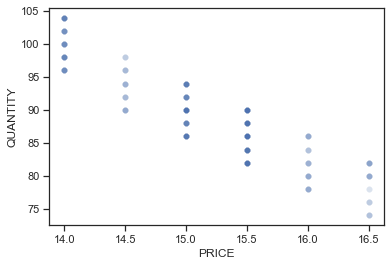

```python
burger_1070 = bau2_data[(bau2_data['ITEM_NAME'] == 'BURGER') & (bau2_data['SELL_ID'] == 1070)]

burger_1070.head()
burger_1070.describe()
sns.scatterplot(data = burger_1070, x = burger_1070.PRICE, y = burger_1070.QUANTITY, alpha = 0.1)
```

```
                            OLS Regression Results
==============================================================================
Dep. Variable:               QUANTITY   R-squared:                       0.813
Model:                            OLS   Adj. R-squared:                  0.813
Method:                 Least Squares   F-statistic:                     1804.
Date:                Mon, 07 Jun 2021   Prob (F-statistic):          5.51e-153
Time:                        21:38:27   Log-Likelihood:                -1038.8
No. Observations:                 416   AIC:                             2082.
Df Residuals:                     414   BIC:                             2090.
Df Model:                           1
Covariance Type:            nonrobust
==============================================================================
                 coef    std err          t      P>|t|      [0.025      0.975]
------------------------------------------------------------------------------
Intercept    220.3600      3.090     71.322      0.000     214.287     226.433
PRICE         -8.6586      0.204    -42.474      0.000      -9.059      -8.258
==============================================================================
Omnibus:                      281.738   Durbin-Watson:                   1.989
Prob(Omnibus):                  0.000   Jarque-Bera (JB):               25.687
Skew:                           0.012   Prob(JB):                     2.64e-06
Kurtosis:                       1.783   Cond. No.                         326.
==============================================================================

Notes:
[1] Standard Errors assume that the covariance matrix of the errors is correctly specified.
```

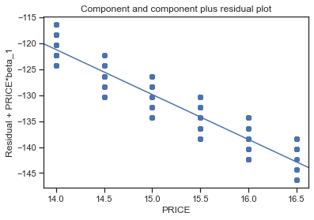

```python
burger_model = ols("QUANTITY ~ PRICE", data=burger_1070).fit()
print(burger_model.summary())
fig = plt.figure(figsize=(12,8))
fig = sm.graphics.plot_ccpr(burger_model, "PRICE")
```

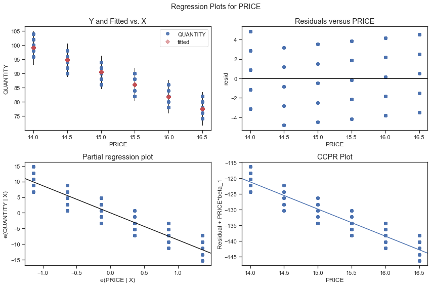

```python
fig = plt.figure(figsize=(12,8))
fig = sm.graphics.plot_regress_exog(burger_model, "PRICE", fig=fig)
```

|  | SELL_ID | SELL_CATEGORY | ITEM_NAME | CALENDAR_DATE | PRICE | QUANTITY | YEAR | HOLIDAY | IS_WEEKEND | IS_SCHOOLBREAK | AVERAGE_TEMPERATURE | IS_OUTDOOR |
| --- | --- | --- | --- | --- | --- | --- | --- | --- | --- | --- | --- | --- |
| 1 | 2051 | 2 | BURGER | 1/13/12 | 12.73 | 40 | 2012 | No Holiday | 0 | 0 | 26.6 | 0 |
| 9 | 2051 | 2 | BURGER | 1/13/13 | 13.13 | 26 | 2013 | No Holiday | 1 | 0 | 30.2 | 0 |
| 17 | 2051 | 2 | BURGER | 1/13/14 | 13.27 | 38 | 2014 | No Holiday | 0 | 0 | 28.4 | 0 |
| 25 | 2051 | 2 | BURGER | 1/13/15 | 11.53 | 38 | 2015 | No Holiday | 0 | 0 | 28.4 | 0 |
| 33 | 2051 | 2 | BURGER | 1/14/12 | 12.73 | 24 | 2012 | No Holiday | 1 | 0 | 23.0 | 0 |

|  | SELL_ID | SELL_CATEGORY | PRICE | QUANTITY | YEAR | IS_WEEKEND | IS_SCHOOLBREAK | AVERAGE_TEMPERATURE | IS_OUTDOOR |
| --- | --- | --- | --- | --- | --- | --- | --- | --- | --- |
| count | 837.0 | 837.0 | 837.000000 | 837.000000 | 837.000000 | 837.000000 | 837.000000 | 837.000000 | 837.000000 |
| mean | 2051.0 | 2.0 | 12.368017 | 29.498208 | 2013.351254 | 0.284349 | 0.200717 | 56.255914 | 0.878136 |
| std | 0.0 | 0.0 | 0.726329 | 5.782878 | 1.063043 | 0.451373 | 0.400776 | 20.005316 | 0.327324 |
| min | 2051.0 | 2.0 | 10.970000 | 12.000000 | 2012.000000 | 0.000000 | 0.000000 | 14.000000 | 0.000000 |
| 25% | 2051.0 | 2.0 | 11.530000 | 26.000000 | 2012.000000 | 0.000000 | 0.000000 | 35.600000 | 1.000000 |
| 50% | 2051.0 | 2.0 | 12.660000 | 30.000000 | 2013.000000 | 0.000000 | 0.000000 | 59.000000 | 1.000000 |
| 75% | 2051.0 | 2.0 | 13.080000 | 34.000000 | 2014.000000 | 1.000000 | 0.000000 | 75.200000 | 1.000000 |
| max | 2051.0 | 2.0 | 13.270000 | 46.000000 | 2015.000000 | 1.000000 | 1.000000 | 87.800000 | 1.000000 |

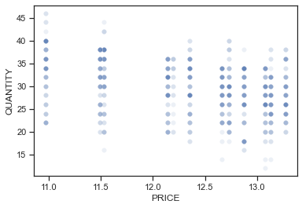

```python
burger_2051 = combined_data[(combined_data['ITEM_NAME'] == 'BURGER') & (combined_data['SELL_ID'] == 2051)]

burger_2051.head()
burger_2051.describe()
sns.scatterplot(data = burger_2051, x = burger_2051.PRICE, y = burger_2051.QUANTITY, alpha = 0.1)
```

```
                            OLS Regression Results
==============================================================================
Dep. Variable:               QUANTITY   R-squared:                       0.130
Model:                            OLS   Adj. R-squared:                  0.129
Method:                 Least Squares   F-statistic:                     124.7
Date:                Mon, 07 Jun 2021   Prob (F-statistic):           4.45e-27
Time:                        21:38:28   Log-Likelihood:                -2597.8
No. Observations:                 837   AIC:                             5200.
Df Residuals:                     835   BIC:                             5209.
Df Model:                           1
Covariance Type:            nonrobust
==============================================================================
                 coef    std err          t      P>|t|      [0.025      0.975]
------------------------------------------------------------------------------
Intercept     64.9906      3.184     20.411      0.000      58.741      71.240
PRICE         -2.8697      0.257    -11.166      0.000      -3.374      -2.365
==============================================================================
Omnibus:                       24.502   Durbin-Watson:                   1.779
Prob(Omnibus):                  0.000   Jarque-Bera (JB):               22.439
Skew:                          -0.347   Prob(JB):                     1.34e-05
Kurtosis:                       2.599   Cond. No.                         213.
==============================================================================

Notes:
[1] Standard Errors assume that the covariance matrix of the errors is correctly specified.
```

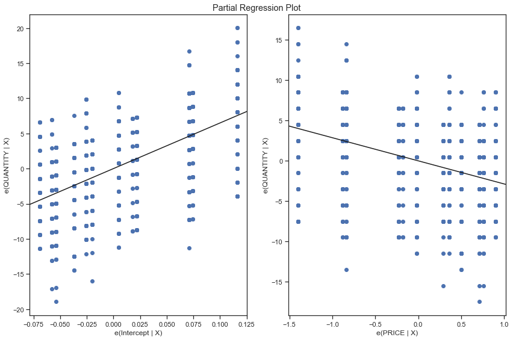

```python
burger_model = ols("QUANTITY ~ PRICE", data=burger_2051).fit()
print(burger_model.summary())
fig = plt.figure(figsize=(12,8))
fig = sm.graphics.plot_partregress_grid(burger_model, fig=fig)
```

|  | SELL_ID | SELL_CATEGORY | ITEM_NAME | CALENDAR_DATE | PRICE | QUANTITY | YEAR | HOLIDAY | IS_WEEKEND | IS_SCHOOLBREAK | AVERAGE_TEMPERATURE | IS_OUTDOOR |
| --- | --- | --- | --- | --- | --- | --- | --- | --- | --- | --- | --- | --- |
| 2 | 2051 | 2 | COKE | 1/13/12 | 12.73 | 40 | 2012 | No Holiday | 0 | 0 | 26.6 | 0 |
| 7 | 2053 | 2 | COKE | 1/13/12 | 12.60 | 58 | 2012 | No Holiday | 0 | 0 | 26.6 | 0 |
| 10 | 2051 | 2 | COKE | 1/13/13 | 13.13 | 26 | 2013 | No Holiday | 1 | 0 | 30.2 | 0 |
| 15 | 2053 | 2 | COKE | 1/13/13 | 13.41 | 32 | 2013 | No Holiday | 1 | 0 | 30.2 | 0 |
| 18 | 2051 | 2 | COKE | 1/13/14 | 13.27 | 38 | 2014 | No Holiday | 0 | 0 | 28.4 | 0 |

```
(1674, 12)
```

|  | SELL_ID | SELL_CATEGORY | PRICE | QUANTITY | YEAR | IS_WEEKEND | IS_SCHOOLBREAK | AVERAGE_TEMPERATURE | IS_OUTDOOR |
| --- | --- | --- | --- | --- | --- | --- | --- | --- | --- |
| count | 1674.000000 | 1674.0 | 1674.000000 | 1674.000000 | 1674.000000 | 1674.000000 | 1674.000000 | 1674.000000 | 1674.000000 |
| mean | 2052.000000 | 2.0 | 12.151326 | 38.150538 | 2013.351254 | 0.284349 | 0.200717 | 56.255914 | 0.878136 |
| std | 1.000299 | 0.0 | 0.871405 | 11.861375 | 1.062726 | 0.451239 | 0.400656 | 19.999336 | 0.327226 |
| min | 2051.000000 | 2.0 | 10.450000 | 12.000000 | 2012.000000 | 0.000000 | 0.000000 | 14.000000 | 0.000000 |
| 25% | 2051.000000 | 2.0 | 11.490000 | 30.000000 | 2012.000000 | 0.000000 | 0.000000 | 35.600000 | 1.000000 |
| 50% | 2052.000000 | 2.0 | 12.370000 | 36.000000 | 2013.000000 | 0.000000 | 0.000000 | 59.000000 | 1.000000 |
| 75% | 2053.000000 | 2.0 | 12.770000 | 48.000000 | 2014.000000 | 1.000000 | 0.000000 | 75.200000 | 1.000000 |
| max | 2053.000000 | 2.0 | 13.410000 | 74.000000 | 2015.000000 | 1.000000 | 1.000000 | 87.800000 | 1.000000 |

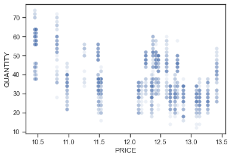

```python
coke = combined_data[combined_data['ITEM_NAME'] == 'COKE']
coke.head()
coke.shape
coke.describe()
sns.scatterplot(x = coke.PRICE, y = coke.QUANTITY , alpha = 0.1)
```

```
                            OLS Regression Results
==============================================================================
Dep. Variable:               QUANTITY   R-squared:                       0.246
Model:                            OLS   Adj. R-squared:                  0.245
Method:                 Least Squares   F-statistic:                     544.2
Date:                Mon, 07 Jun 2021   Prob (F-statistic):          1.94e-104
Time:                        21:38:29   Log-Likelihood:                -6279.2
No. Observations:                1674   AIC:                         1.256e+04
Df Residuals:                    1672   BIC:                         1.257e+04
Df Model:                           1
Covariance Type:            nonrobust
==============================================================================
                 coef    std err          t      P>|t|      [0.025      0.975]
------------------------------------------------------------------------------
Intercept    120.1140      3.522     34.100      0.000     113.205     127.023
PRICE         -6.7452      0.289    -23.329      0.000      -7.312      -6.178
==============================================================================
Omnibus:                      122.436   Durbin-Watson:                   2.565
Prob(Omnibus):                  0.000   Jarque-Bera (JB):               47.133
Skew:                           0.154   Prob(JB):                     5.82e-11
Kurtosis:                       2.238   Cond. No.                         172.
==============================================================================

Notes:
[1] Standard Errors assume that the covariance matrix of the errors is correctly specified.
```

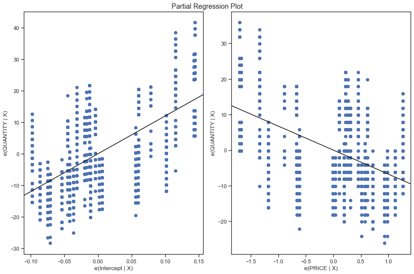

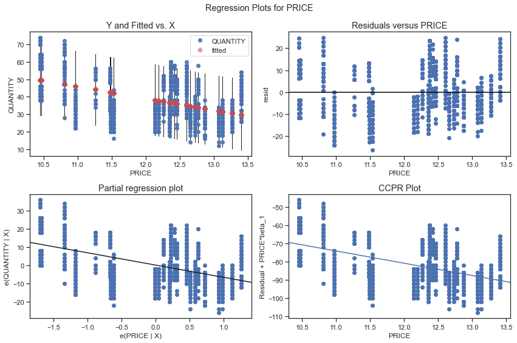

```python
coke_model = ols("QUANTITY ~ PRICE", data=coke).fit()
print(coke_model.summary())
fig = plt.figure(figsize=(12,8))
fig = sm.graphics.plot_partregress_grid(coke_model, fig=fig)
fig = plt.figure(figsize=(12,8))
fig = sm.graphics.plot_regress_exog(coke_model, 'PRICE', fig=fig)
```

|  | SELL_ID | SELL_CATEGORY | ITEM_NAME | CALENDAR_DATE | PRICE | QUANTITY | YEAR | HOLIDAY | IS_WEEKEND | IS_SCHOOLBREAK | AVERAGE_TEMPERATURE | IS_OUTDOOR |
| --- | --- | --- | --- | --- | --- | --- | --- | --- | --- | --- | --- | --- |
| 6 | 2053 | 2 | COFFEE | 1/13/12 | 12.60 | 58 | 2012 | No Holiday | 0 | 0 | 26.6 | 0 |
| 14 | 2053 | 2 | COFFEE | 1/13/13 | 13.41 | 32 | 2013 | No Holiday | 1 | 0 | 30.2 | 0 |
| 22 | 2053 | 2 | COFFEE | 1/13/14 | 12.37 | 60 | 2014 | No Holiday | 0 | 0 | 28.4 | 0 |
| 30 | 2053 | 2 | COFFEE | 1/13/15 | 10.81 | 66 | 2015 | No Holiday | 0 | 0 | 28.4 | 0 |
| 38 | 2053 | 2 | COFFEE | 1/14/12 | 12.60 | 42 | 2012 | No Holiday | 1 | 0 | 23.0 | 0 |

```
(837, 12)
```

|  | SELL_ID | SELL_CATEGORY | PRICE | QUANTITY | YEAR | IS_WEEKEND | IS_SCHOOLBREAK | AVERAGE_TEMPERATURE | IS_OUTDOOR |
| --- | --- | --- | --- | --- | --- | --- | --- | --- | --- |
| count | 837.0 | 837.0 | 837.000000 | 837.000000 | 837.000000 | 837.000000 | 837.000000 | 837.000000 | 837.000000 |
| mean | 2053.0 | 2.0 | 11.934636 | 46.802867 | 2013.351254 | 0.284349 | 0.200717 | 56.255914 | 0.878136 |
| std | 0.0 | 0.0 | 0.947643 | 9.909910 | 1.063043 | 0.451373 | 0.400776 | 20.005316 | 0.327324 |
| min | 2053.0 | 2.0 | 10.450000 | 20.000000 | 2012.000000 | 0.000000 | 0.000000 | 14.000000 | 0.000000 |
| 25% | 2053.0 | 2.0 | 10.810000 | 40.000000 | 2012.000000 | 0.000000 | 0.000000 | 35.600000 | 1.000000 |
| 50% | 2053.0 | 2.0 | 12.370000 | 48.000000 | 2013.000000 | 0.000000 | 0.000000 | 59.000000 | 1.000000 |
| 75% | 2053.0 | 2.0 | 12.600000 | 54.000000 | 2014.000000 | 1.000000 | 0.000000 | 75.200000 | 1.000000 |
| max | 2053.0 | 2.0 | 13.410000 | 74.000000 | 2015.000000 | 1.000000 | 1.000000 | 87.800000 | 1.000000 |

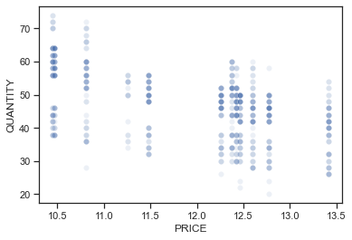

```python
df = combined_data[combined_data['ITEM_NAME'] == 'COFFEE']
df.head()
df.shape
df.describe()
sns.scatterplot(x = df.PRICE, y = df.QUANTITY , alpha = 0.1)
```

```
                            OLS Regression Results
==============================================================================
Dep. Variable:               QUANTITY   R-squared:                       0.281
Model:                            OLS   Adj. R-squared:                  0.281
Method:                 Least Squares   F-statistic:                     327.0
Date:                Mon, 07 Jun 2021   Prob (F-statistic):           6.20e-62
Time:                        21:38:31   Log-Likelihood:                -2968.5
No. Observations:                 837   AIC:                             5941.
Df Residuals:                     835   BIC:                             5951.
Df Model:                           1
Covariance Type:            nonrobust
==============================================================================
                 coef    std err          t      P>|t|      [0.025      0.975]
------------------------------------------------------------------------------
Intercept    113.0116      3.673     30.770      0.000     105.803     120.220
PRICE         -5.5476      0.307    -18.084      0.000      -6.150      -4.945
==============================================================================
Omnibus:                       42.439   Durbin-Watson:                   1.699
Prob(Omnibus):                  0.000   Jarque-Bera (JB):               38.502
Skew:                          -0.463   Prob(JB):                     4.36e-09
Kurtosis:                       2.505   Cond. No.                         152.
==============================================================================

Notes:
[1] Standard Errors assume that the covariance matrix of the errors is correctly specified.
```

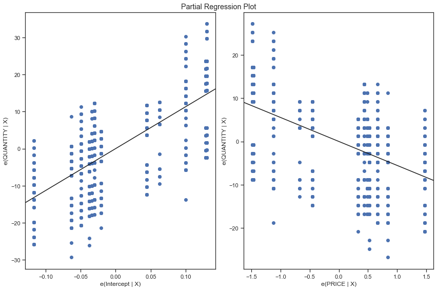

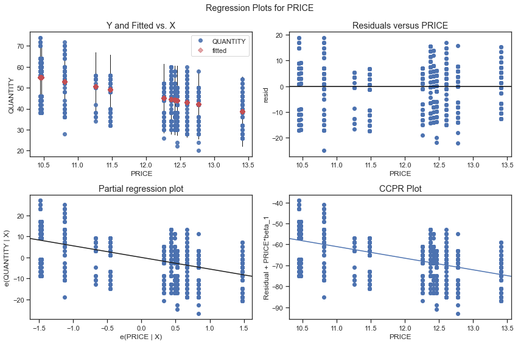

```python
model = ols("QUANTITY ~ PRICE", data=df).fit()
print(model.summary())
fig = plt.figure(figsize=(12,8))
fig = sm.graphics.plot_partregress_grid(model, fig=fig)
fig = plt.figure(figsize=(12,8))
fig = sm.graphics.plot_regress_exog(model, 'PRICE', fig=fig)
```

|  | SELL_ID | SELL_CATEGORY | ITEM_NAME | CALENDAR_DATE | PRICE | QUANTITY | YEAR | HOLIDAY | IS_WEEKEND | IS_SCHOOLBREAK | AVERAGE_TEMPERATURE | IS_OUTDOOR |
| --- | --- | --- | --- | --- | --- | --- | --- | --- | --- | --- | --- | --- |
| 4 | 2052 | 2 | LEMONADE | 1/13/12 | 12.75 | 26 | 2012 | No Holiday | 0 | 0 | 26.6 | 0 |
| 12 | 2052 | 2 | LEMONADE | 1/13/13 | 12.64 | 18 | 2013 | No Holiday | 1 | 0 | 30.2 | 0 |
| 20 | 2052 | 2 | LEMONADE | 1/13/14 | 11.96 | 24 | 2014 | No Holiday | 0 | 0 | 28.4 | 0 |
| 28 | 2052 | 2 | LEMONADE | 1/13/15 | 11.45 | 28 | 2015 | No Holiday | 0 | 0 | 28.4 | 0 |
| 36 | 2052 | 2 | LEMONADE | 1/14/12 | 12.75 | 20 | 2012 | No Holiday | 1 | 0 | 23.0 | 0 |

```
(837, 12)
```

|  | SELL_ID | SELL_CATEGORY | PRICE | QUANTITY | YEAR | IS_WEEKEND | IS_SCHOOLBREAK | AVERAGE_TEMPERATURE | IS_OUTDOOR |
| --- | --- | --- | --- | --- | --- | --- | --- | --- | --- |
| count | 837.0 | 837.0 | 837.000000 | 837.000000 | 837.000000 | 837.000000 | 837.000000 | 837.000000 | 837.000000 |
| mean | 2052.0 | 2.0 | 11.976918 | 20.910394 | 2013.351254 | 0.284349 | 0.200717 | 56.255914 | 0.878136 |
| std | 0.0 | 0.0 | 0.820698 | 4.514501 | 1.063043 | 0.451373 | 0.400776 | 20.005316 | 0.327324 |
| min | 2052.0 | 2.0 | 10.120000 | 8.000000 | 2012.000000 | 0.000000 | 0.000000 | 14.000000 | 0.000000 |
| 25% | 2052.0 | 2.0 | 11.360000 | 18.000000 | 2012.000000 | 0.000000 | 0.000000 | 35.600000 | 1.000000 |
| 50% | 2052.0 | 2.0 | 12.260000 | 20.000000 | 2013.000000 | 0.000000 | 0.000000 | 59.000000 | 1.000000 |
| 75% | 2052.0 | 2.0 | 12.720000 | 24.000000 | 2014.000000 | 1.000000 | 0.000000 | 75.200000 | 1.000000 |
| max | 2052.0 | 2.0 | 12.850000 | 34.000000 | 2015.000000 | 1.000000 | 1.000000 | 87.800000 | 1.000000 |

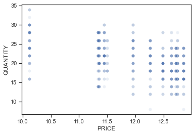

```python
df = combined_data[combined_data['ITEM_NAME'] == 'LEMONADE']
df.head()
df.shape
df.describe()
sns.scatterplot(x = df.PRICE, y = df.QUANTITY , alpha = 0.1)
```